# A study of the socio-economic and geographic aspects of detainment since the Myanmar Coup in 2021

Abhilash Biswas, Jaison Jose, Vidisha Chowdhury

09/12/2021

## Abstract

On 1 February 2021, the quasi-democratic government of Myanmar was overthrown by the Tatmadaw - the Burmese military in a coup d’état which sparked a series of protests in the country. Owing to the brutal response of the military to the peaceful demonstrations, people have started resorting to more violent forms of resistance such as paramilitary training to oppose the Tatmadaw. In response, the military has been attempting to aggressively eliminate resistance in the country. According to the Assistance Association for Political Prisoners (AAPP), nearly 1,300 people have been killed by the junta and more than 10,000 have been arrested since the coup. This analysis is an attempt to characterise detainment in Myanmar. We study individual level attributes such as gender and age distribution of detainees, look at the association between detainment, imprisonment and deaths. In addition, our township level analysis tries to examine if detainment is associated with some socio-economic, demographic or geographic patterns in Myanmar.

## Introduction

Since the military coup in Myanmar, many civilians and opposition forces have been detained, imprisoned, and killed. The Assistance Association for Political Prisoners (AAPP) records these occurrences along with the names, gender, designation and additional attributes of people involved in these incidents. Since February 2021, as the Burmese military adopts more violent ways to curb public resistance, there is a growing consensus among people that the military needs to be countered using more aggressive forms of opposition. In certain parts of the country, civilians are training with firearms and hand grenades making it evident that the country is on the brink of a civil war.

Media reports suggest that the military has been targeting areas that are home to armed civilians known as the People’s Defense Force. It has been reported that there has been a large buildup of troops in the northwest of Myanmar. According to residents, fire rockets have been launched, homes burnt down, food supplies cut and civilians attempting to escape have been shot.

## Methods

The three data sets we use and their sources are outlined below.

1. Data on detainment, imprisonment and death of political prisoners - AAPP
2. Historical data on Myanmar indicators at the township level - Myanmar Information Management Unit (MIMU)
3. A derived data set on conflicts and protests in Myanmar in 2021 - Armed Conflict Location & Event Data Project (ACLED)

## 1. Cleaning and merging

### a. Cleaning all the individual datasets

```r
#Importing necessary libraries

library(tidyverse)
library(modelsummary)
library(knitr)


#DETAINEES

  ## Import detainees dataset
  detainees = read_csv("https://www.andrew.cmu.edu/user/jweiss2/21f_r/94842/final_2021/detained.csv.gz")


#Checking number of missing values in all columns

sapply(detainees, function(x) (sum(is.na(x))/length(x))*100)
```

```
##                No              Name               Sex               Age
##         0.0596214         0.2384856         0.2682963        70.6960799
##     Father's Name            Status    Date of Arrest    Section of Law
##        64.0333880         0.3875391         5.4553585        80.6975704
##         Plaintiff Current Condition           Address      Region/State
##        96.2885676         0.1341482         1.4905351         1.9973170
##            Remark
##        61.9615442
```

```r
#Drop missing values by name and Serial number
detainees = detainees %>%
                  drop_na(Name) %>%
                  drop_na(No)

total_detained = length(detainees$Name) #Unique detainees


# Tabulating data type of each column

data.frame("Type" = sapply(detainees, function(x) typeof(x)))
```

```
##                        Type
## No                   double
## Name              character
## Sex               character
## Age               character
## Father's Name     character
## Status            character
## Date of Arrest    character
## Section of Law    character
## Plaintiff         character
## Current Condition character
## Address           character
## Region/State      character
## Remark            character
```

```r
# Converting Age into a numeric column


detainees =   detainees %>%
                mutate(Age_1 =
                  case_when(str_detect(Age, "Under") ~ "18",
                            ## Just two observations for under 18, therefore dropped
                            str_detect(Age, "[a-zA-Z]") ~ "NA",
                            str_detect(Age, "2000.0") ~ "NA",
                            str_detect(Age, "3000000000.0") ~ "NA",
                            str_detect(Age, "\\)") ~ "NA",
                            T ~ Age

                            ))

detainees$Age_1[detainees$Age_1 == "NA"] = NA

detainees$Age_1 = as.numeric(detainees$Age_1)

detainees$Age = detainees$Age_1

# Converting Sex into a factor column

detainees =   detainees %>%
                mutate(Sex_1 =
                  case_when(str_detect(Sex, "[a-zA-Z]*M[a-zA-Z]*") ~ "M",
                            str_detect(Sex, "[a-zA-Z]*F[a-zA-Z]*") ~ "F",
                            str_detect(Sex, "[^M|^F]]*") ~ "NA",
                            T ~ Sex

                            ))

detainees$Sex_1[detainees$Sex_1 == "NA"] = NA
detainees$Sex_1 = factor(detainees$Sex_1, levels = c("F","M"))


detainees$Sex = detainees$Sex_1

detainees = subset(detainees, select = -c(Sex_1, Age_1))


# Tabulating unique values in each column

data.frame("Unique_Values" = sapply(detainees, function(x) length(unique(x))))
```

```
##                   Unique_Values
## No                         6689
## Name                       5336
## Sex                           3
## Age                          72
## Father's Name              1446
## Status                      782
## Date of Arrest              366
## Section of Law              144
## Plaintiff                    76
## Current Condition           149
## Address                    2087
## Region/State                151
## Remark                      666
```

```r
#Missing Sex
missing_sex_detainees = sum(is.na(detainees$Sex))

#Missing Age
missing_age_detainees = sum(is.na(detainees$Age))

  #Parsing the status column to get designation of detained people
  detainees = detainees %>%
                  mutate(designation =
                    case_when(str_detect(Status, "MP") ~ "MP or Former MP",
                              str_detect(Status, "NLD") ~ "NLD",
                              str_detect(Status, "Other Parties") ~ "Other Parties",
                              str_detect(Status, "Public Servant") ~ "Public Servant",
                              str_detect(Status, "Religious") ~ "Religious person",
                              str_detect(Status, "Minister") ~ "Government Minister",
                              str_detect(Status, "Civilian") ~ "Civilian",
                              str_detect(Status, "Medic") ~ "Medical Professional",
                              str_detect(Status, "Student") ~ "Student",
                              str_detect(Status, "Education") ~ "Academic professional",
                              str_detect(Status, "Teacher") ~ "Academic professional",
                              str_detect(Status, "Admin") ~ "Administrative staff (any level of state)",
                              str_detect(Status, "Media") ~ "Media Person",
                              str_detect(Status, "Reporter") ~ "Media Person",
                              str_detect(Status, "Activist") ~ "Activist",
                              str_detect(Status, "CSO") ~ "Activist",

                              T ~ "Other Misc"
                              )
                    )
  unique_designations_detainees = unique(detainees$designation)


  #Getting township names from address for merging
  detainees = detainees %>%
    mutate(township = str_replace_all(Address,".*,","")) %>%
    mutate(township = str_replace_all(township,"T?own.*",""))

  #Getting month of detainment (to be used for analysis later)

  detainees = detainees %>%
                mutate(month = case_when(
                                str_detect(`Date of Arrest`, "[0-9]{1,2}-[a-zA-Z]{3}-[0-9]{1,2}") ~
                                           str_extract(`Date of Arrest`, "-[a-zA-Z]{3}-"),
                                         T ~ "NA")) %>%

                mutate(month = case_when(str_detect(`month`,  "-[a-zA-Z]{3}-") ~
                                           str_extract(month, "[a-zA-Z]{3}"),
                                         T ~ "NA"))
  detainees$month[detainees$month == "NA"] = NA

  #Converting into a tibble with nested individual level data
  nested.det = detainees %>% nest(data_det=-township)
  unique_townships_det = nrow(nested.det)

###############################################################################
#IMPRISONMENT

  #Importing the dataset
  imprisoned = read_csv("https://www.andrew.cmu.edu/user/jweiss2/21f_r/94842/final_2021/imprisoned.csv.gz")

  #Changing the sex column name
  names(imprisoned)[names(imprisoned) == 'Sex /Age'] = 'Sex'

  #Drop missing values by name and Serial number
  imprisoned = imprisoned %>%
                    drop_na(Name) %>%
                    drop_na(No)
  total_imprisoned = length(imprisoned$Name) #Unique imprisoned

#Checking number of missing values in all columns

sapply(imprisoned, function(x) (sum(is.na(x))/length(x))*100)
```

```
##                No              Name               Sex               Age
##         0.0000000         0.0000000         0.0000000        86.6013072
##     Father's Name            Status    Date of Arrest    Section of Law
##        61.4379085         0.0000000        11.1111111        18.9542484
##         Plaintiff Current Condition            Prison           Address
##        93.7908497         0.6535948        29.4117647         0.9803922
##     Region/Sta te            Remark
##         1.9607843        21.2418301
```

```r
#Drop missing values by name and Serial number
imprisoned = imprisoned %>%
                  drop_na(Name) %>%
                  drop_na(No)

total_imprisoned = length(imprisoned$Name) #Unique imprisoned


# Converting Age into a numeric column


imprisoned =   imprisoned %>%
                mutate(Age_1 =
                  case_when(str_detect(Age, "[a-zA-Z]") ~ "NA",
                            T ~ Age
                            ))

imprisoned$Age_1[imprisoned$Age_1 == "NA"] = NA

imprisoned$Age_1 = as.numeric(imprisoned$Age_1)

imprisoned$Age = imprisoned$Age_1

# Converting Sex into a factor column

imprisoned =   imprisoned %>%
                mutate(Sex_1 =
                  case_when(str_detect(Sex, "[a-zA-Z]*M[a-zA-Z]*") ~ "M",
                            str_detect(Sex, "[a-zA-Z]*F[a-zA-Z]*") ~ "F",
                            str_detect(Sex, "[^M|^F]]*") ~ "NA",
                            T ~ Sex

                            ))

imprisoned$Sex_1[imprisoned$Sex_1 == "NA"] = NA
imprisoned$Sex_1 = factor(imprisoned$Sex_1, levels = c("F","M"))

imprisoned$Sex = imprisoned$Sex_1

imprisoned = subset(imprisoned, select = -c(Sex_1, Age_1))


# Tabulating unique values in each column

 data.frame("Unique_Values" = sapply(imprisoned, function(x) length(unique(x))))
```

```
##                   Unique_Values
## No                          306
## Name                        295
## Sex                           2
## Age                          25
## Father's Name               102
## Status                       55
## Date of Arrest               74
## Section of Law               67
## Plaintiff                    11
## Current Condition            49
## Prison                       28
## Address                      97
## Region/Sta te                22
## Remark                      126
```

```r
  #Sex
  missing_sex_imprisoned = sum(is.na(imprisoned$Sex))

  #Missing Age
  missing_age_imprisoned = sum(is.na(imprisoned$Age))

  #Parsing the status column to get designation of imprisoned people
  imprisoned = imprisoned %>%
                  mutate(designation =
                    case_when(str_detect(Status, "MP") ~ "MP or Former MP",
                              str_detect(Status, "NLD") ~ "NLD",
                              str_detect(Status, "Other Parties") ~ "Other Parties",
                              str_detect(Status, "Public Servant") ~ "Public Servant",
                              str_detect(Status, "Religious") ~ "Religious person",
                              str_detect(Status, "Minister") ~ "Government Minister",
                              str_detect(Status, "Civilian") ~ "Civilian",
                              str_detect(Status, "Medic") ~ "Medical Professional",
                              str_detect(Status, "Student") ~ "Student",
                              str_detect(Status, "Education") ~ "Academic professional",
                              str_detect(Status, "Teacher") ~ "Academic professional",
                              str_detect(Status, "Admin") ~ "Administrative staff (any level of state)",
                              str_detect(Status, "Media") ~ "Media Person",
                              str_detect(Status, "Reporter") ~ "Media Person",
                              str_detect(Status, "Activist") ~ "Activist",
                              str_detect(Status, "CSO") ~ "Activist",

                              T ~ "Other Misc"
                              )
                    )
  unique_designations_imprisoned = unique(imprisoned$designation)


  #Getting township names from address for merging
  imprisoned = imprisoned %>%
    mutate(township = str_replace_all(Address,".*,","")) %>%
    mutate(township = str_replace_all(township,"T?own.*",""))

  #Getting month of imprisonment (to be used for analysis later)

  imprisoned = imprisoned %>%
                  mutate(month = case_when(str_detect(`Date of Arrest`,
                                                    "[0-9]{1,2}-[a-zA-Z]{3}-[0-9]{1,2}") ~
                                           str_extract(`Date of Arrest`, "-[a-zA-Z]{3}-"),
                                           str_detect(`Date of Arrest`,
                                                    "Mar") ~ "Mar",
                                           str_detect(`Date of Arrest`,
                                                    "Sep") ~ "Sep",
                                           str_detect(`Date of Arrest`,
                                                    "Apr") ~ "Apr",
                                         T ~ "NA"))%>%

    mutate(month = case_when(str_detect(`month`,
                                        "-[a-zA-Z]{3}-") ~
                                           str_extract(month, "[a-zA-Z]{3}"),
                                         T ~ month))
  imprisoned$month[imprisoned$month == "NA"] = NA


  #Converting into a tibble with nested individual level data
  nested.imp = imprisoned %>% nest(data_imp=-township)
  unique_townships_imp = nrow(nested.imp)



###############################################################################

#FALLEN

  #Importing the dataset
  fallen = read_csv("https://www.andrew.cmu.edu/user/jweiss2/21f_r/94842/final_2021/fallen.csv")

  #Drop missing values by name and Serial number
  fallen = fallen %>%
                  drop_na(Name) %>%
                  drop_na(No.)
  total_fallen = length(fallen$Name) #Unique imprisoned

 #Checking number of missing values in all columns

sapply(fallen, function(x) (sum(is.na(x))/length(x))*100)
```

```
##                No.               Name                Sex                Age
##           0.000000           0.000000           1.830283          23.710483
##      Father's name   Date of Incident      Deceased Date       Organization
##           1.414309           1.497504           2.329451           1.247920
## Place of Incidents       Home Address           Township     States/Regions
##          10.565724          35.357737           4.242928           2.329451
##            Remarks
##          25.124792
```

```r
#Drop missing values by name and Serial number
fallen = fallen %>%
                drop_na(Name) %>%
                drop_na(No.)

total_fallen = length(fallen$Name) #Unique imprisoned

# Converting Age into a numeric column


fallen =   fallen %>%
                mutate(Age_1 =
                  case_when(str_detect(Age, "[a-zA-Z]") ~ "NA",
                            str_detect(Age, "[0-9] ?+") ~ str_extract(Age, "[0-9]{2}"),
                            T ~ Age
                            ))

fallen$Age_1[fallen$Age_1 == "NA"] = NA

fallen$Age_1 = as.numeric(fallen$Age_1)

fallen$Age = fallen$Age_1

# Converting Sex into a factor column

fallen =   fallen %>%
                mutate(Sex_1 =
                  case_when(str_detect(Sex, "[a-zA-Z]*M [a-zA-Z]*") ~ "M",
                            str_detect(Sex, "[a-zA-Z]*F [a-zA-Z]*") ~ "F",
                            str_detect(Sex, "[^M|^F]]*") ~ "NA",
                            T ~ Sex

                            ))

fallen$Sex_1[fallen$Sex_1 == "NA"] = NA
fallen$Sex_1 = factor(fallen$Sex_1, levels = c("F","M"))

fallen$Sex = fallen$Sex_1

fallen = subset(fallen, select = -c(Sex_1, Age_1))


# Tabulating unique values in each column

data.frame("Unique_Values" = sapply(fallen, function(x) length(unique(x))))
```

```
##                    Unique_Values
## No.                         1202
## Name                        1072
## Sex                            3
## Age                           67
## Father's name                210
## Date of Incident             220
## Deceased Date                227
## Organization                 114
## Place of Incidents           468
## Home Address                 614
## Township                     213
## States/Regions                22
## Remarks                      535
```

```r
  #Sex
  missing_sex_fallen = sum(is.na(fallen$Sex))

  #Missing Age
 missing_age_fallen = sum(is.na(fallen$Age))

  #Parsing the Organization column to get designation of fallen people
  fallen = fallen %>%
                  mutate(designation =
                    case_when(str_detect(Organization, "MP") ~ "MP or Former MP",
                              str_detect(Organization, "NLD") ~ "NLD",
                              str_detect(Organization, "Other Parties") ~ "Other Parties",
                              str_detect(Organization, "Public Servant") ~ "Public Servant",
                              str_detect(Organization, "Religious") ~ "Religious person",
                              str_detect(Organization, "Minister") ~ "Government Minister",
                              str_detect(Organization, "Civilian") ~ "Civilian",
                              str_detect(Organization, "Medic") ~ "Medical Professional",
                              str_detect(Organization, "Student") ~ "Student",
                              str_detect(Organization, "Education") ~ "Academic professional",
                              str_detect(Organization, "Teacher") ~ "Academic professional",
                              str_detect(Organization, "Admin") ~ "Administrative staff (any level of state)",
                              str_detect(Organization, "Media") ~ "Media Person",
                              str_detect(Organization, "Reporter") ~ "Media Person",
                              str_detect(Organization, "Activist") ~ "Activist",
                              str_detect(Organization, "CSO") ~ "Activist",

                              T ~ "Other Misc"
                              )
                    )
  unique_designations_fallen = unique(fallen$designation)



  #Cleaning existing township names
  fallen = fallen %>%
    mutate(township = str_replace_all(Township,".*,","")) %>%
    mutate(township = str_replace_all(township,"T?own.*","")) %>%
    dplyr::mutate(Township = str_extract(Township, '[^\\(]+'))

  #Getting month of fallen (to be used for analysis later)
  fallen = fallen %>% mutate(month = case_when(str_detect(`Date of Incident`,
                                                    "[0-9]{1,2}-[a-zA-Z]{3}-[0-9]{1,2}") ~
                                           str_extract(`Date of Incident`, "-[a-zA-Z]{3}-"),

                                         T ~ "NA"))%>%

    mutate(month = case_when(str_detect(`month`,
                                        "-[a-zA-Z]{3}-") ~
                                           str_extract(month, "[a-zA-Z]{3}"),
                                         T ~ month))
  fallen$month[fallen$month == "NA"] = NA



  #Converting into a tibble with nested individual level data
  nested.fal = fallen %>% nest(data_fal=-township)
  unique_townships_fal = nrow(nested.fal)

###############################################################################

#CONFLICTS

  #Importing the dataset
  conflicts = read_csv("https://www.andrew.cmu.edu/user/jweiss2/21f_r/94842/final_2021/conflicts.csv.gz")

  #Generating township name
  conflicts = conflicts %>%
    mutate(township = str_replace_all(admin3,".*,","")) %>%
    mutate(township = str_replace_all(township,"T?own.*",""))


  #Converting into a tibble with nested individual level data
  nested.fal = fallen %>% nest(data_fal=-township)
  unique_townships_fal = nrow(nested.fal)

  #Creating a dataframe of actors
  actors = c('State Forces','Rebel Groups','Political Militias','Identity Militias','Rioters','Protesters','Civilians','External;/Other forces','no actor')
  code = c(1,2,3,4,5,6,7,8,0)

  actor_codes = data.frame(code,actors)

  #Dropping existing actor names (as they don't reflect the broad category)
  conflicts = subset(conflicts, select = -c(actor1,actor2) )

  #Now merging with the conflicts dataset
  conflicts = merge(conflicts,actor_codes, by.x = "inter1", by.y = "code" )
  names(conflicts)[names(conflicts) == 'actors'] = 'actor1'

  conflicts = merge(conflicts,actor_codes, by.x = "inter2", by.y = "code" )
  names(conflicts)[names(conflicts) == 'actors'] = 'actor2'

  total_conflicts = nrow(conflicts)

  #Converting into a tibble with nested individual level data
  nested.conf = conflicts %>% nest(data_conf=-township)
  unique_townships_conf = nrow(nested.conf)
```

In this section we clean all the individual datasets, namely:

- Detainees
- Imprisoned
- Fallen
- Conflicts

For each individual datasets, the following broad cleaning steps were followed:

1. Drop rows containing no names for individuals
2. Clean the Sex column (to be used for analysis later)
3. Clean the Status column to extract the designation of individuals
4. Extract the month of the incident that took place
5. Convert each dataset to a nested tibble at a township level

Based on the cleaning performed, below are some summary numbers:

1. Detainees dataset
1. There are a total of 1967 unique townships in the detainees dataset. However, some of them may be random text and not actual township names.
2. Out of 6689 observations in the detainees dataset, 17 had missing Sex values
3. Out of 6689 observations in the detainees dataset, 4755 had missing age values
2. Imprisoned dataset
1. There are a total of 96 unique townships in the imprisoned dataset. However, some of them may be random text and not actual township names.
2. Out of 306 observations in the imprisoned dataset, 0 had missing Sex values
3. Out of 306 observations in the imprisoned dataset, 267 had missing age values
3. Fallen dataset
1. There are a total of 213 unique townships in the fallen dataset. However, some of them may be random text and not actual township names.
2. Out of 1202 observations in the fallen dataset, 33 had missing Sex values
3. Out of 1202 observations in the fallen dataset, 300 had missing age values
3. Conflicts dataset
1. There are a total of 314 unique townships in the conflicts dataset. However, some of them may be random text and not actual township names.
2. There are a total of 14188 reported in this dataset.
3. There are a total of 8 unique actors involved in these conflicts.

### b. Getting the sector indicators and merging

```r
#Reading in the sectors (MIMU) dataset
tmp = tempfile(fileext = ".xlsm")
httr::GET(
  url = "https://www.andrew.cmu.edu/user/jweiss2/21f_r/94842/final_2021/MIMU_BaselineData_AllSectors_Countrywide_18Mar2021_revised.xlsm",
  httr::write_disk(tmp)
)
```

```
## Response [https://www.andrew.cmu.edu/user/jweiss2/21f_r/94842/final_2021/MIMU_BaselineData_AllSectors_Countrywide_18Mar2021_revised.xlsm]
##   Date: 2021-12-10 02:46
##   Status: 200
##   Content-Type: application/vnd.ms-excel.sheet.macroEnabled.12
##   Size: 19.3 MB
## <ON DISK>  C:\Users\vidis\AppData\Local\Temp\RtmpYNN19f\file2cc850672e7c.xlsm
```

```r
sector.indicators =
  readxl::read_xlsx(tmp, sheet=3, skip = 5) %>% as_tibble()

#Condensing the sectors dataframe into a tibble with nested data per indicator
sector.nest = sector.indicators %>%
                select(1:3,
                       Indicator_Name, Indicator_Type, Sector, Unit,
                       starts_with("20"), Source_Name) %>%

                mutate(
                       Indicator = paste(Indicator_Name, Indicator_Type,
                                         Sector, Unit, Source_Name, sep="|")) %>%

                select(1:3,
                       Indicator, starts_with("20")) %>%

                pivot_longer(cols = starts_with("20"),
                             names_to = "Year",
                             values_to="Value") %>%

                filter(!is.na(Value)) %>%
                nest(data = -Indicator) %>%
                separate(Indicator, sep="\\|",
                         into = c("Indicator_Name", "Indicator_Type",
                                  "Sector","Unit","Source_Name"))


#Creating the leven function to be used in merging on township names later
leven = function(x, y, k=0, ignore.case=T) {
  data.frame(y=y) %>%
    as_tibble() %>%

    # compute Levenshtein distance for string x for each y
    mutate(distance = utils::adist(x, y,
                                   ignore.case=ignore.case) %>% .[1,]) %>%

    # keep y's within k of the best match
    filter(distance <= min(distance, na.rm=T) + k) %>%
    mutate(distance.per.char = distance/nchar(y))
}

# Use `leven` for string *vectors* `x` and `y`
apply_leven = function(x, y, k=0, distance.threshold=0.3, ignore.case=F) {
  data.frame(x=x) %>%
    # get potential matches for each x as a list of tibbles
    mutate(leven.df = map(x, ~ leven(.x, y=y,
                                     k=k, ignore.case=ignore.case))
    ) %>%
    unnest(everything()) %>%
    mutate(is.match=distance.per.char < distance.threshold) %>%

    # order by best match
    arrange(distance.per.char) %>%

    # keep the best match per `x`
    group_by(x) %>%
    slice(1) %>%
    ungroup() %>%

    # convert non-matches to Other
    mutate(y = ifelse(is.match, y, "Other"))
}


#Adding indicators available from census
township.values = sector.nest %>%
  filter(
           Indicator_Name == "Proportion of female-headed households" |
           Indicator_Name == "Population size" |
           Indicator_Name == "Urban Population as Percentage of Total Population" |
           Indicator_Name == "Age dependency ratio" |
           Indicator_Name == "Child dependency ratio" |
           Indicator_Name == "Sex ratio" |
           Indicator_Name == "Adult literacy rate" |
           Indicator_Name == "Number of Households by source of lighting" |
           Indicator_Name == "Percentage of households with safe sanitation" |
           Indicator_Name == "Percentage of Households' use of drinking water by source" ,

           Indicator_Type=="Total"|
           Indicator_Type == "Electricity - Total"|
           Indicator_Type=="Improved sources - Total",

         str_detect(Source_Name, "Census")) %>%
  unnest(everything())

#Adding additional indicators from other sources
add_indi.values = sector.nest %>%
  filter(Indicator_Name == "Infant mortality rate" |
         Indicator_Name == "Township hospital" |
         Indicator_Name == "Children Immunized (BCG)" |
         Indicator_Name == "Malnutrition under three years" |
         Indicator_Name == "Battles" |
         Indicator_Name == "Fatalities" |
         Indicator_Name == "Non-Dependent population" |
         Indicator_Name == "Wealth Ranking Index" |
         Indicator_Name == "Approximate Vulnerable Population",

         Indicator_Type=="Total") %>%
          unnest(everything())

#Appending the 2 above dataframes together
township.values = rbind(township.values, add_indi.values)

#Pivoting the dataset to have one row per unique township
township.values = township.values %>%
                    pivot_wider(names_from = Indicator_Name,
                                values_from=Value,
                                id_cols = Township_Name)

#Getting the last values for some of the indicators as they represent the latest year from which the value was extracted
extract_last = function(x) {
    x[length(x)]
}

#Applying the above function on a bunch of township.values columns
township.values$`Infant mortality rate` = sapply(township.values$`Infant mortality rate`, extract_last)
township.values$`Children Immunized (BCG)` = sapply(township.values$`Children Immunized (BCG)`, extract_last)
township.values$`Malnutrition under three years` = sapply(township.values$`Malnutrition under three years`, extract_last)
township.values$`Age dependency ratio` = sapply(township.values$`Age dependency ratio`, extract_last)
township.values$`Child dependency ratio` = sapply(township.values$`Child dependency ratio`, extract_last)
township.values$`Population size` = sapply(township.values$`Population size`, extract_last)
township.values$`Proportion of female-headed households` = sapply(township.values$`Proportion of female-headed households`, extract_last)
township.values$`Sex ratio` = sapply(township.values$`Sex ratio`, extract_last)
township.values$`Urban Population as Percentage of Total Population` = sapply(township.values$`Urban Population as Percentage of Total Population`, extract_last)
township.values$`Number of Households by source of lighting` = sapply(township.values$`Number of Households by source of lighting`, extract_last)
township.values$`Percentage of households with safe sanitation` = sapply(township.values$`Percentage of households with safe sanitation`, extract_last)
township.values$`Percentage of Households' use of drinking water by source` = sapply(township.values$`Percentage of Households' use of drinking water by source`, extract_last)
township.values$`Township hospital` <- sapply(township.values$`Township hospital`, extract_last)

#Converting NULL to 0
township.values = township.values %>%
                      mutate_all(funs(str_replace_all(.,"NULL","0")))


#Removing any remaining non numeric rows and converting columns to numeric

columns = c(colnames(township.values))
columns = columns[-1]
township.values[columns] = sapply(township.values[columns],as.numeric)

#Creating a short table listing all chosen indicators
indicators = colnames(township.values)
indicators = indicators[-1] #Removing the township name variable from the list

rationale = c(
              "To see if number of dependent population in a township affects detainment",
              "Same as above",
              "An essential control while comparing detainee counts across townships",
              "Interesting indicator of social dynamics in a town",
              "Since male and female may have different detainment rates",
              "To see if detainments happen more in urban or rural areas",
              "To see if more literate population are detained in higher numbers",
              "Indicator of development status of the town",
              "Indicator of development status of the town",
              "Indicator of development status of the town",
              "Similar rationale as for Age dependency ratio",
              "Same as above",
              "Indicator of wealth",
              "Important health indicator for a town",
              "Same as above",
              "Same as above",
              "Same as above",
              "To see if more battles lead to more detainment",
              "To see if fatalities and detainment is correlated"

)

indicator_table = data.frame(indicators,rationale)

###  Now creating some merged datasets for analysis

# 1. merged_data_det = detainees merged with MIMU indicators
# 2. merged_data_det_conf = detainees merged with MIMU indicators merged with conflict data
# 3. merged_data_det_imp = detainees merged with MIMU indicators merged with imprisoned data
# 4. merged_data_det_fal = detainees merged with MIMU indicators merged with fallen data



#merged_data_det

merged_data_det = nested.det %>%
                inner_join(apply_leven(.$township,
                                       township.values$Township_Name,
                                       distance.threshold=0.28),
                           by=c("township"="x")
                ) %>%

                rename(detainee_township=township, MIMU_township=y) %>%

                group_by(MIMU_township) %>%
                summarise(detainees = sum(map_dbl(data_det,nrow))) %>%
                ungroup() %>%

                left_join(township.values, by=c("MIMU_township"="Township_Name")) %>%
                filter(MIMU_township!="Other")

#Saving null value counts
null_vals = sapply(merged_data_det, function(x) (sum(is.null(x))/length(x))*100)

#None of the columns have any null values

#merged_data_det_conf
merged_data_det_conf = nested.conf %>%
                inner_join(apply_leven(.$township,
                                       township.values$Township_Name,
                                       distance.threshold=0.28),
                           by=c("township"="x")
                ) %>%

                rename(conflict_township=township, MIMU_township=y) %>%

                group_by(MIMU_township) %>%
                summarise(conflicts = sum(map_dbl(data_conf,nrow))) %>%
                ungroup() %>%

                left_join(merged_data_det, by=c("MIMU_township"="MIMU_township")) %>%
                filter(!is.na(detainees)) %>%
                filter(MIMU_township!="Other")


#merged_data_det_imp

merged_data_det_imp = nested.imp%>%
                inner_join(apply_leven(.$township,
                                       township.values$Township_Name,
                                       distance.threshold=0.28),
                           by=c("township"="x")
                ) %>%

                rename(imprisoned_township=township, MIMU_township=y) %>%

                group_by(MIMU_township) %>%
                summarise(imprisoned = sum(map_dbl(data_imp,nrow))) %>%
                ungroup() %>%

                left_join(merged_data_det, by=c("MIMU_township"="MIMU_township")) %>%
                filter(!is.na(detainees)) %>%
                filter(MIMU_township!="Other")


#merged_data_det_fal

merged_data_det_fal = nested.fal%>%
                inner_join(apply_leven(.$township,
                                       township.values$Township_Name,
                                       distance.threshold=0.28),
                           by=c("township"="x")
                ) %>%

                rename(fallen_township=township, MIMU_township=y) %>%

                group_by(MIMU_township) %>%
                summarise(fallen = sum(map_dbl(data_fal,nrow))) %>%
                ungroup() %>%

                left_join(merged_data_det, by=c("MIMU_township"="MIMU_township")) %>%
                filter(!is.na(detainees)) %>%
                filter(MIMU_township!="Other")
```

In this section, we have picked certain indicators from the MIMU dataset and merged it with township level detainee, fallen, imprisoned and conflict counts for our analysis.

#### Key datasets

1. merged_data_det = detainees merged with MIMU indicators
1. Number of unique townships = 170
2. We have a total of 1831 detainees in this dataset as compared to 6689 in the individual detainees dataset.
2. merged_data_det_conf = detainees merged with MIMU indicators merged with conflict data
1. Number of unique townships = 166
2. We have a total of 1814 detainees in this dataset as compared to 6689 in the individual detainees dataset.
3. We have a total of 8764 conflicts in this dataset as compared to 14188 in the individual detainees dataset.
4. This is the dataset we will use primarily for our analysis

This suggests that in the merging process, we have lost quite a bit of individual counts of detainees and fallen. For our subsequent analysis, we have assumed that if a town is not present in the above datasets, then the count of the appropriate variable (for example total detained) for that township is 0.

#### Socio-economic variables chosen

Below is a list of the socio economic indicators chosen and a brief rationale:

| indicators | rationale |
| --- | --- |
| Age dependency ratio | To see if number of dependent population in a township affects detainment |
| Child dependency ratio | Same as above |
| Population size | An essential control while comparing detainee counts across townships |
| Proportion of female-headed households | Interesting indicator of social dynamics in a town |
| Sex ratio | Since male and female may have different detainment rates |
| Urban Population as Percentage of Total Population | To see if detainments happen more in urban or rural areas |
| Adult literacy rate | To see if more literate population are detained in higher numbers |
| Number of Households by source of lighting | Indicator of development status of the town |
| Percentage of households with safe sanitation | Indicator of development status of the town |
| Percentage of Households’ use of drinking water by source | Indicator of development status of the town |
| Approximate Vulnerable Population | Similar rationale as for Age dependency ratio |
| Non-Dependent population | Same as above |
| Wealth Ranking Index | Indicator of wealth |
| Infant mortality rate | Important health indicator for a town |
| Township hospital | Same as above |
| Children Immunized (BCG) | Same as above |
| Malnutrition under three years | Same as above |
| Battles | To see if more battles lead to more detainment |
| Fatalities | To see if fatalities and detainment is correlated |

## 2. Tabulations

In this section, we conduct some brief counts of different variables to get a sense of how detainment varies across different characteristics.

### a. Distribution of detainees, imprisoned and fallen by gender (Univariate)

####Distribution of detainees by Sex

```r
knitr::kable(detainees[!is.na(detainees$Sex),] %>% group_by(Sex) %>% summarise(Count = n()))
```

| Sex | Count |
| --- | --- |
| F | 1245 |
| M | 5427 |

####Distribution of imprisoned by Sex

```r
knitr::kable(imprisoned[!is.na(imprisoned$Sex),] %>% group_by(Sex) %>% summarise(Count = n()))
```

| Sex | Count |
| --- | --- |
| F | 56 |
| M | 250 |

####Distribution of fallen by Sex

```r
knitr::kable((fallen[!is.na(fallen$Sex),] %>% group_by(Sex) %>% summarise(Count = n())))
```

| Sex | Count |
| --- | --- |
| F | 84 |
| M | 1085 |

From these tables, we can see that male citizens are detained, imprisoned and fallen at a disproportionately higher count. However, there could be a lot of biases in play here. Firstly, the sex ratio may be skewed towards men in the overall population. Further, if males are disproportionately represented in government service (which was a source of a lot of protests against this coup), it would lead to higher counts of men for detainment as well as other categories.

### b. Distribution of detainees by designation (Univariate)

```r
knitr::kable(detainees %>% group_by(designation) %>% summarise(Count = n()))
```

| designation | Count |
| --- | --- |
| Academic professional | 110 |
| Activist | 33 |
| Administrative staff (any level of state) | 55 |
| Civilian | 5335 |
| Government Minister | 24 |
| Media Person | 43 |
| Medical Professional | 67 |
| MP or Former MP | 49 |
| NLD | 207 |
| Other Misc | 370 |
| Public Servant | 21 |
| Religious person | 44 |
| Student | 331 |

### c. Top 5 and bottom 5 detainee townships and the number of imprisoned in each (Multivariate)

```r
table = merged_data_det_imp[,1:3]
table = table %>% arrange(desc(detainees))
knitr::kable(table[c(1:5,(nrow(table)-4):nrow(table)),])
```

| MIMU_township | imprisoned | detainees |
| --- | --- | --- |
| Monywa | 1 | 97 |
| Myeik | 3 | 93 |
| North Okkalapa | 15 | 48 |
| Bago | 2 | 44 |
| Dawei | 18 | 43 |
| Thayetchaung | 6 | 8 |
| Tachileik | 4 | 6 |
| Kawthoung | 2 | 5 |
| Kyangin | 2 | 5 |
| Tanintharyi | 2 | 1 |

### d. Top 5 and bottom 5 detainee townships and their socio economic indicators (Multivariate)

```r
table = merged_data_det[,c("MIMU_township",
                           "detainees",
                           "Number of Households by source of lighting",
                           "Infant mortality rate",
                           "Malnutrition under three years",
                           "Percentage of Households' use of drinking water by source",
                           "Township hospital")]

table = table %>% rename (
                    "electricity_access" = "Number of Households by source of lighting",
                    "under_3_malnutrition" = "Malnutrition under three years",
                    "IMR" = "Infant mortality rate",
                    "improved_drinking_water_access" = "Percentage of Households' use of drinking water by source"
)

table = table %>% arrange(desc(detainees))

knitr::kable(table[c(1:5,(nrow(table)-4):nrow(table)),])
```

| MIMU_township | detainees | electricity_access | IMR | under_3_malnutrition | improved_drinking_water_access | Township hospital |
| --- | --- | --- | --- | --- | --- | --- |
| Monywa | 97 | 51104 | 19.5 | 12.6 | 93.30 | 0 |
| Myeik | 93 | 5721 | 6.8 | 1.9 | 86.58 | 0 |
| Thingangyun | 74 | 42137 | 14.8 | 1.2 | 99.36 | 0 |
| Insein | 55 | 55409 | 31.0 | 1.7 | 98.97 | 1 |
| Myitkyina | 54 | 26777 | 7.2 | 3.0 | 90.96 | 0 |
| Shwedaung | 1 | 9512 | 16.5 | 1.4 | 88.36 | 1 |
| Shwegu | 1 | 3571 | 34.6 | 1.2 | 87.79 | 1 |
| Tanintharyi | 1 | 1214 | 1.7 | 2.6 | 44.59 | 1 |
| Tatkon | 1 | 9394 | 9.2 | 0.2 | 85.12 | 1 |
| Wundwin | 1 | 12862 | 14.6 | 1.6 | 92.11 | 1 |

This table provides some interesting observations. Higher detainment towns have higher electricity access. This may indicate that more developed towns also had higher detainment. We will see later how urban population in a town affects detainment. It is important to note that both detainment and counts of electricity access can just be positively correlated with population size.

We do not see much of a difference in Infant mortality rate, malnutrition rate and access to improved drinking water rate to be associated with detainment counts. However, townships that had higher detainment also seem to not have township hospitals existing in them.

## 3. Data descriptions and visualizations

We’ll be showcasing visualizations of interesting inferences that we were able to glean from the data set.

### 3.a Wealth Ranking index distribution (Univariate)

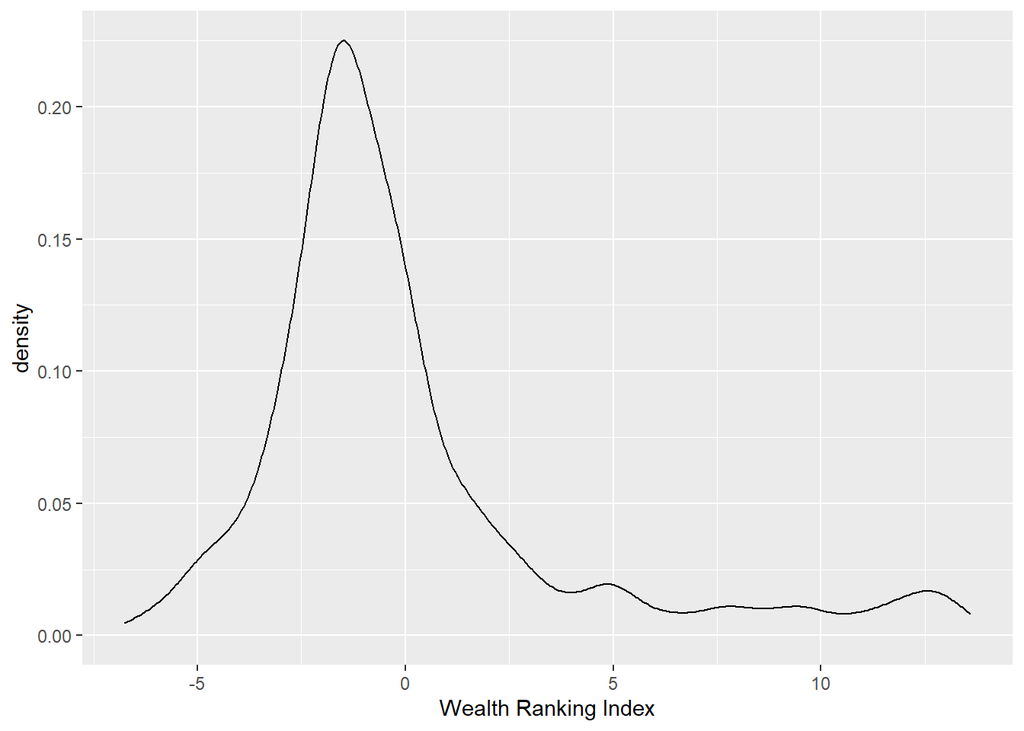

```r
ggplot(data = township.values, aes(x=`Wealth Ranking Index`)) + geom_density()
```

(Due the absence of an exact definition of wealth index in the MIMU codebook, we assume that the wealth index is a composite measure of a household’s cumulative living standard calculated using data on a household’s ownership of selected assets. https://dhsprogram.com/topics/wealth-index/)

The sample distribution of the wealth index across townships shows that the variable is likely to have an asymmetric distribution since its distribution is positively skewed.

The density graph indicates that a high fraction of townships have a lower wealth ranking ranking (below 5)

### 3.b Distribution of Children immunised with BCG (Univariate)

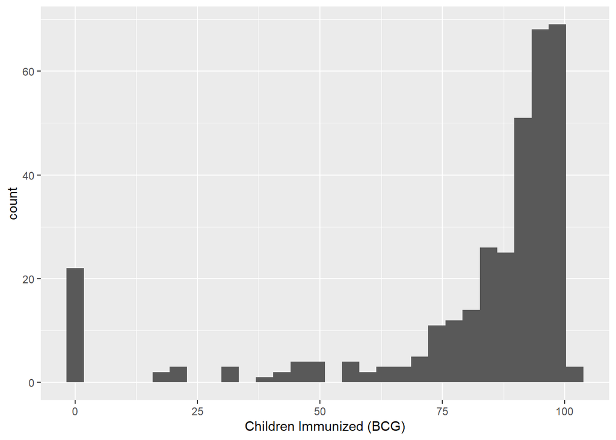

```r
ggplot(data = township.values, aes(x=`Children Immunized (BCG)`)) + geom_histogram()
```

The distribution of child immunization rates suggests that while a significant chunk of the townships have achieved above 80% or complete BCG immunization, there are about 21 townships with immunization rates close to zero.

### 3.c Relationship between township detainee count and literacy rate (Bivariate)

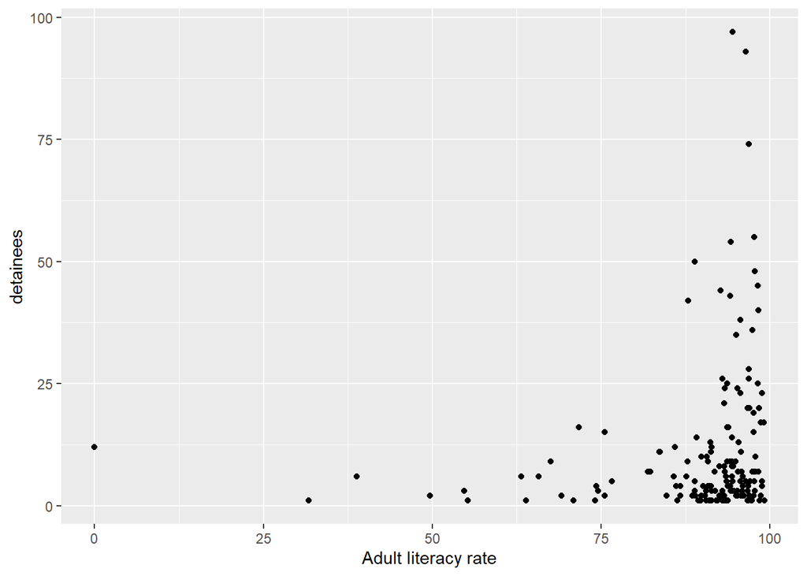

```r
ggplot(merged_data_det, aes(x = `Adult literacy rate`, y = detainees)) + geom_point()
```

We can see that townships with higher literacy rate had more number of detainees. Its possible that there was a targeted attempt to capture the more literate part of the population to quell future resistance.

### 3.d Relationship between township detainee count and proportion of urban population (Bivariate)

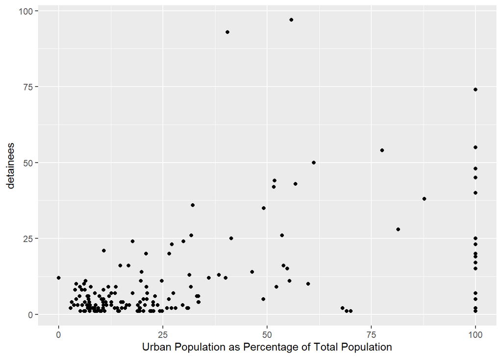

```r
ggplot(merged_data_det, aes(x = `Urban Population as Percentage of Total Population`, y = detainees)) + geom_point()
```

We can see here that townships with lower urban population had lesser detainment. We later investigate if this relation is statistically significant.

### 3.e Relationship between township detainee count and proportion of female headed households (Bivariate)

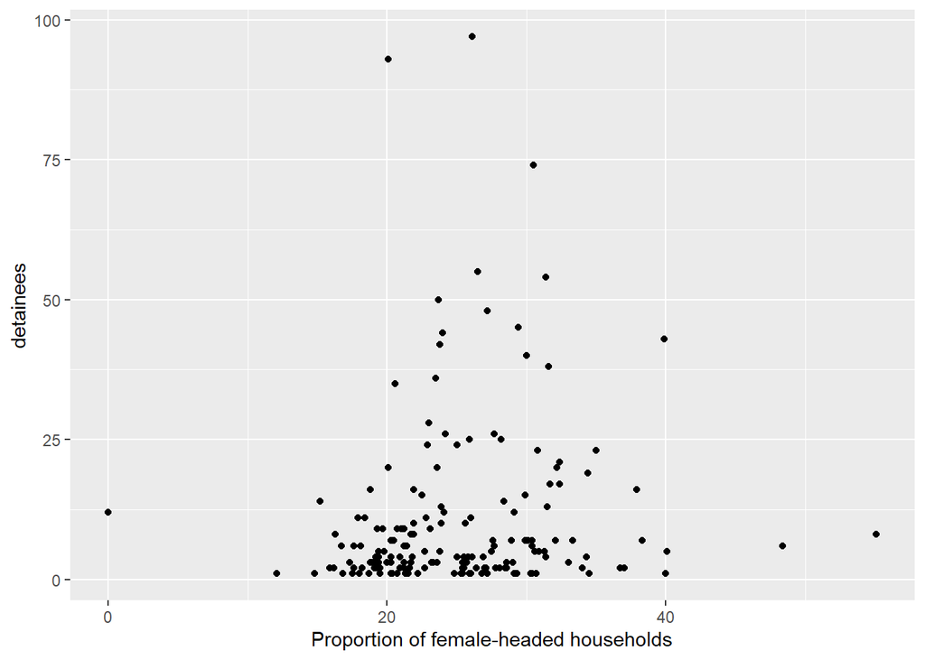

```r
ggplot(merged_data_det, aes(x = `Proportion of female-headed households`, y = detainees)) + geom_point()
```

While no clear trend seems to emerge, one can see a lot of variation in detainee counts in townships which had 20-40% of female headed households.

### 3.f Number of conflicts and fatalities by actor (Trivariate)

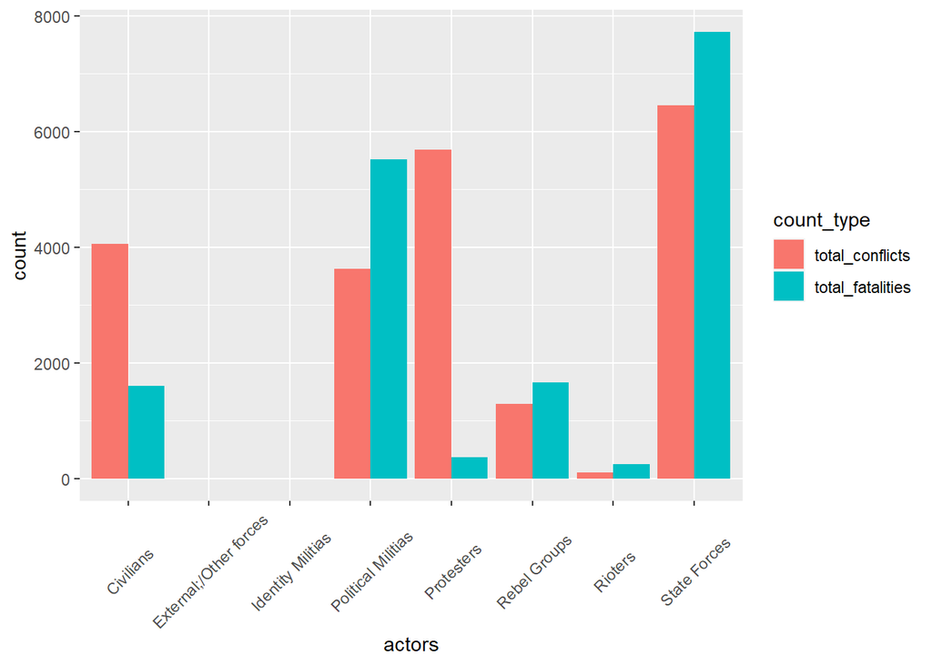

```r
#Create a dataframe to plot your visualization

actors = unique(conflicts$actor1)
conflicts[actors]  = 0

#Creating a column per actor to generate counts
conflicts = conflicts %>%
              mutate(`State Forces` = ifelse(                                                actor1 == "State Forces" |                                                actor2 == "State Forces", 1,0)) %>%
              mutate(`Protesters` = ifelse(                                                  actor1 == "Protesters" |                                                  actor2 == "Protesters", 1, 0)) %>%
              mutate(`Political Militias` = ifelse(
                   actor1 == "Political Militias" |
                   actor2 == "Political Militias", 1, 0)) %>%
              mutate(`Rioters` = ifelse(
                   actor1 == "Rioters" |
                   actor2 == "Rioters", 1, 0)) %>%
              mutate(`Rebel Groups` = ifelse(
                   actor1 == "Rebel Groups" |
                   actor2 == "Rebel Groups", 1, 0)) %>%
              mutate(`Civilians` = ifelse(
                   actor1 == "Civilians" |
                   actor2 == "Civilians", 1, 0)) %>%
              mutate(`External;/Other forces` = ifelse(
                   actor1 == "External;/Other forces" |
                   actor2 == "External;/Other forces", 1, 0)) %>%
              mutate(`Identity Militias` = ifelse(
                   actor1 == "Identity Militias" |
                     actor2 == "Identity Militias", 1, 0))



total_conflicts = c(sum(conflicts$`State Forces`), sum(conflicts$`Protesters`), sum(conflicts$`Political Militias`),
                    sum(conflicts$`Rioters`), sum(conflicts$`Rebel Groups`), sum(conflicts$`Civilians`),
                    sum(conflicts$`External;/Other forces`), sum(conflicts$`Identity Militias`))

total_fatalities = c(sum(conflicts[which(conflicts$`State Forces`==1), 15]), sum(conflicts[which(conflicts$`Protesters`==1), 15]),
                     sum(conflicts[which(conflicts$`Political Militias`==1), 15]),
                     sum(conflicts[which(conflicts$`Rioters`==1), 15]),
                     sum(conflicts[which(conflicts$`Rebel Groups`==1), 15]), sum(conflicts[which(conflicts$`Civilians`==1), 15]),
                     sum(conflicts[which(conflicts$`External;/Other forces`==1), 15]),
                     sum(conflicts[which(conflicts$`Identity Militias`==1), 15]))


data = data.frame(actors,total_conflicts,total_fatalities)
data = data %>%
          pivot_longer(!actors, names_to = "count_type", values_to = "count") %>%
          arrange(-count, actors )

#Plotting
ggplot(data, aes(x = actors, y = count, fill = count_type)) +
  geom_col(position = "dodge") + theme(axis.text.x=element_text(angle = 45, vjust = 0.5))
```

Civilians have a disproportionate number of fatalities as a percentage of it’s total conflicts, when compared to the other two. This could mean that even if civilians are part of conflicts they suffer lesser fatalitites.

### 3.g Detainees, fallen and imprisoned over time (Trivariate)

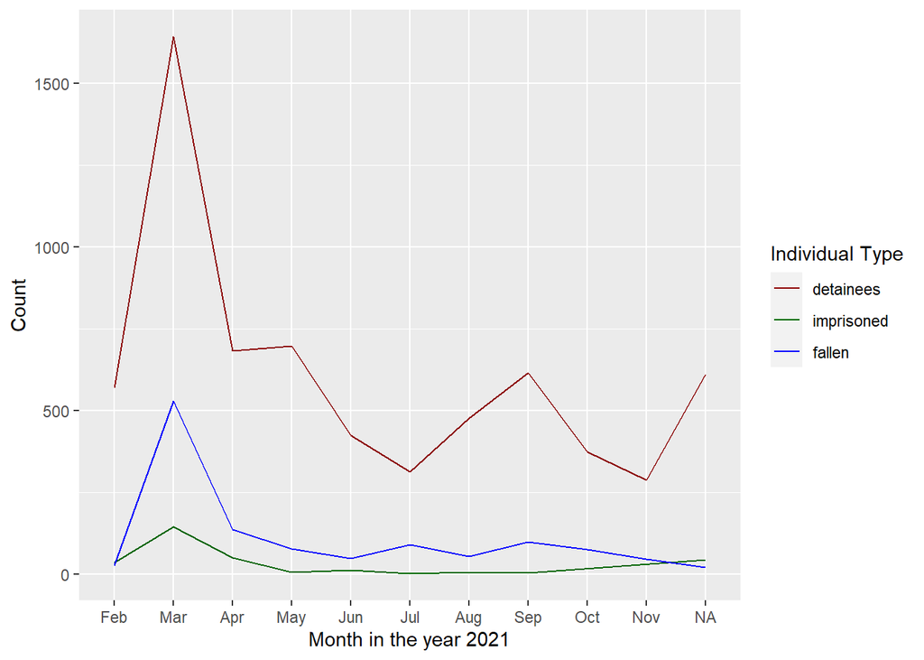

```r
d = data.frame(detainees %>% group_by(detainees$month) %>% summarise(detainee_ct = n()))
d = rename(d,month = "detainees.month")
d$month = factor(d$month, levels = c("Jan","Feb","Mar","Apr","May","Jun","Jul","Aug","Sep","Oct","Nov","Dec"))
i = data.frame(imprisoned %>% group_by(imprisoned$month) %>% summarise(imprisoned_ct = n()))
i = rename(i,month = "imprisoned.month")
i$month = factor(i$month, levels = c("Jan","Feb","Mar","Apr","May","Jun","Jul","Aug","Sep","Oct","Nov","Dec"))
f = data.frame(fallen %>% group_by(fallen$month) %>% summarise(fallen_ct = n()))
f= rename(f,month = "fallen.month")
f$month = factor(f$month, levels = c("Jan","Feb","Mar","Apr","May","Jun","Jul","Aug","Sep","Oct","Nov","Dec"))

ggplot(data = d, aes( x=month, y = detainee_ct)) + geom_line(data = d, aes( x=month, y = detainee_ct, group = 1, color = "detainees")) + geom_line(data = i, aes(x=month, y = imprisoned_ct ,group=1, color="imprisoned")) + geom_line(data = f, aes(x=month, y = fallen_ct, group=1, color = "fallen" )) + ylab("Count") +  scale_color_manual(name = "Individual Type", values = c("detainees" = "darkred", "imprisoned" = "darkgreen", "fallen" = "blue")) + xlab("Month in the year 2021")
```

We can see that there is a spike in detainee, imprisoned and fallen counts during march,followed by frequent burst of detainment. This is aligned with the general reports of increased detainment following the coup. Imprisonment and fatalities have generally reduced over time, except for two spikes in July and September.

## 4. Statistical tests

In this section we shall drawing inferences based on the data exploration that we have done. We are forming hypothesis by what we have analyzed above and testing them for statistical significance

### 4.a Checking if proportion of urban population is different in towns which haven’t had any detainment as compared to those which have had atleast 1 detainment

```r
test_data = township.values[,c("Township_Name","Urban Population as Percentage of Total Population")]

test_data = test_data %>%
              left_join(merged_data_det, by=c("Township_Name"="MIMU_township"))

test_data = test_data[,c("Township_Name","detainees","Urban Population as Percentage of Total Population.x")]
test_data$any_detainment[test_data$detainees>0] = 1
test_data$any_detainment[is.na(test_data$any_detainment)] = 0

test_data
```

```
## # A tibble: 337 x 4
##    Township_Name detainees `Urban Population as Percentage of To~ any_detainment
##    <chr>             <dbl>                                  <dbl>          <dbl>
##  1 Bogale                2                                   13.4              1
##  2 Danubyu               6                                   12.1              1
##  3 Dedaye                3                                    7.5              1
##  4 Einme                 2                                    7                1
##  5 Hinthada             11                                   24.7              1
##  6 Ingapu                4                                    6.2              1
##  7 Kangyidaunt           8                                    6.2              1
##  8 Kyaiklat             NA                                   12.7              0
##  9 Kyangin               5                                   20.3              1
## 10 Kyaunggon            NA                                    9.8              0
## # ... with 327 more rows
```

```r
t_test = t.test(`Urban Population as Percentage of Total Population.x` ~ any_detainment, data = test_data)
t_test
```

```
##
##  Welch Two Sample t-test
##
## data:  Urban Population as Percentage of Total Population.x by any_detainment
## t = -3.4267, df = 321.77, p-value = 0.0006902
## alternative hypothesis: true difference in means is not equal to 0
## 95 percent confidence interval:
##  -16.770450  -4.537264
## sample estimates:
## mean in group 0 mean in group 1
##        22.08144        32.73529
```

Townships with urban population have more chances of having detainment than those without.

### 4.b Checking how the wealth ranking index varies between townships having no detainees vs those having atleast 1 detainee

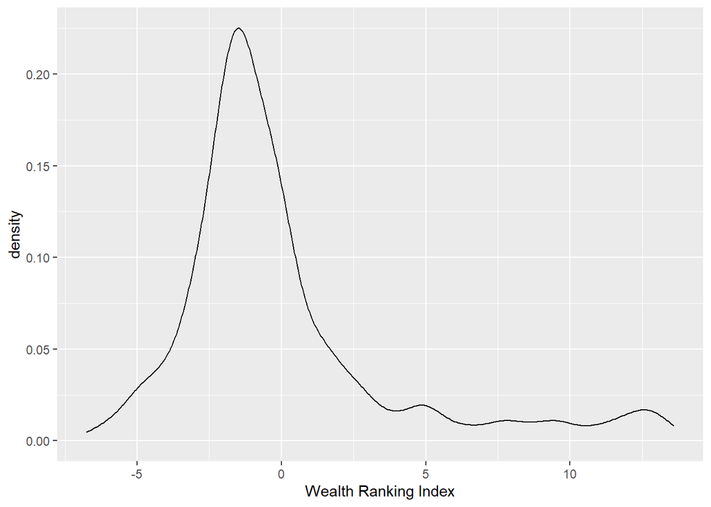

```r
ggplot(data = township.values, aes(x=`Wealth Ranking Index`)) + geom_density()
```

```r
test_data = township.values[,c("Township_Name","Wealth Ranking Index")]

test_data = test_data %>%
              left_join(merged_data_det, by=c("Township_Name"="MIMU_township"))

test_data = test_data[,c("Township_Name","detainees","Wealth Ranking Index.x")]

test_data$any_detainment[test_data$detainees>0] = 1
test_data$any_detainment[is.na(test_data$any_detainment)] = 0

test_data
```

```
## # A tibble: 337 x 4
##    Township_Name detainees `Wealth Ranking Index.x` any_detainment
##    <chr>             <dbl>                    <dbl>          <dbl>
##  1 Bogale                2                   -2.77               1
##  2 Danubyu               6                   -1.37               1
##  3 Dedaye                3                   -2.42               1
##  4 Einme                 2                   -1.96               1
##  5 Hinthada             11                   -1.30               1
##  6 Ingapu                4                   -2.32               1
##  7 Kangyidaunt           8                   -1.86               1
##  8 Kyaiklat             NA                   -1.85               0
##  9 Kyangin               5                   -0.883              1
## 10 Kyaunggon            NA                   -1.86               0
## # ... with 327 more rows
```

```r
wilcox_test = wilcox.test(`Wealth Ranking Index.x` ~ any_detainment, test_data, conf.int=TRUE)
wilcox_test
```

```
##
##  Wilcoxon rank sum test with continuity correction
##
## data:  Wealth Ranking Index.x by any_detainment
## W = 10385, p-value = 2.043e-05
## alternative hypothesis: true location shift is not equal to 0
## 95 percent confidence interval:
##  -1.671132 -0.575284
## sample estimates:
## difference in location
##              -1.094134
```

## 5. Regressions

### 5.a Regressing detainees on all the chosen indicators from MIMU (including population size) at a township level

```r
data = merged_data_det_conf %>% rename (
                    "electricity_access" = "Number of Households by source of lighting",
                    "under_3_malnutrition" = "Malnutrition under three years",
                    "IMR" = "Infant mortality rate",
                    "improved_drinking_water_access" = "Percentage of Households' use of drinking water by source",
                    "prop_female_headed_hh" = "Proportion of female-headed households",
                    "sex_ratio" = "Sex ratio",
                    "prop_urban_population" = "Urban Population as Percentage of Total Population",
                    "percent_safe_sanitation" = "Percentage of households with safe sanitation",
                    "approx_vulnerable_population" = "Approximate Vulnerable Population",


)

data = data %>% subset(select = -MIMU_township)



reg1.lm = lm(detainees ~ ., data = data)

summary(reg1.lm)
```

```
##
## Call:
## lm(formula = detainees ~ ., data = data)
##
## Residuals:
##     Min      1Q  Median      3Q     Max
## -29.091  -5.396  -1.117   4.120  63.928
##
## Coefficients:
##                                  Estimate Std. Error t value Pr(>|t|)
## (Intercept)                    -3.041e+01  2.483e+01  -1.225  0.22258
## conflicts                       9.061e-02  2.233e-02   4.057 8.11e-05 ***
## `Age dependency ratio`          8.640e-01  5.823e-01   1.484  0.14002
## `Child dependency ratio`       -3.495e-01  5.386e-01  -0.649  0.51743
## `Population size`               6.469e-02  4.983e-02   1.298  0.19628
## prop_female_headed_hh          -1.803e-01  1.853e-01  -0.973  0.33224
## sex_ratio                      -1.528e-01  1.647e-01  -0.928  0.35492
## prop_urban_population           2.744e-01  9.228e-02   2.974  0.00345 **
## `Adult literacy rate`          -3.850e-02  1.344e-01  -0.286  0.77498
## electricity_access             -3.118e-04  1.895e-04  -1.645  0.10217
## percent_safe_sanitation         2.536e-02  7.872e-02   0.322  0.74781
## improved_drinking_water_access -3.419e-02  4.799e-02  -0.712  0.47745
## approx_vulnerable_population   -1.940e-04  6.733e-05  -2.882  0.00456 **
## `Non-Dependent population`      2.649e-04  9.680e-05   2.737  0.00698 **
## `Wealth Ranking Index`         -5.577e-01  8.384e-01  -0.665  0.50698
## IMR                            -1.762e-01  1.266e-01  -1.391  0.16633
## `Township hospital`            -4.913e+00  2.375e+00  -2.068  0.04040 *
## `Children Immunized (BCG)`      1.602e-01  6.834e-02   2.344  0.02044 *
## under_3_malnutrition            1.759e-01  4.538e-01   0.388  0.69882
## Battles                        -2.618e-01  2.130e-01  -1.229  0.22102
## Fatalities                      5.584e-02  3.710e-02   1.505  0.13449
## ---
## Signif. codes:  0 '***' 0.001 '**' 0.01 '*' 0.05 '.' 0.1 ' ' 1
##
## Residual standard error: 10.9 on 144 degrees of freedom
##   (1 observation deleted due to missingness)
## Multiple R-squared:  0.5829, Adjusted R-squared:  0.5249
## F-statistic: 10.06 on 20 and 144 DF,  p-value: < 2.2e-16
```

The factors below are all statistically insignificant when it comes to determining the number of detainees in a township.

Age dependency ratio  
Child dependency ratio  
Population size  
prop_female_headed_hh  
sex_ratio  
Adult literacy rate  
electricity_access  
percent_safe_sanitation  
improved_drinking_water_access Wealth Ranking Index IMR  
under_3_malnutrition  
Battles  
Fatalities

This could be due to high collinearity. We shall be determining collinearity and dropping highly collinear variables.

### 5.b Assessing collinearity in the above regression

```r
flattenCorrMatrix <- function(cormat, pmat) {
  ut <- upper.tri(cormat)
  data.frame(
    row = rownames(cormat)[row(cormat)[ut]],
    column = rownames(cormat)[col(cormat)[ut]],
    cor  =(cormat)[ut],
    p = pmat[ut]
    )
}

library(Hmisc)
res2 = rcorr(as.matrix(data[,2:ncol(data)]))
corr_table = flattenCorrMatrix(res2$r, res2$P)

corr_table %>% filter(cor >= 0.7)
```

```
##                            row                       column       cor p
## 1         Age dependency ratio       Child dependency ratio 0.9801850 0
## 2              Population size approx_vulnerable_population 0.8801481 0
## 3              Population size     Non-Dependent population 0.9143501 0
## 4           electricity_access     Non-Dependent population 0.7460249 0
## 5 approx_vulnerable_population     Non-Dependent population 0.7305859 0
## 6        prop_urban_population         Wealth Ranking Index 0.9324241 0
```

We can see that variables on the right have high collinearity with the one’s on the left. We shall be dropping the following variables to reduce collinearity. This helps in making some variables statistically significant as well.

Child dependency ratio approx_vulnerable_population Non-Dependent population Wealth Ranking Index

### 5.c Running a 2nd model after dropping the highly correlated independent variables

```r
#Dropping highly correlated variables

data_trimmed = data %>% subset(select = -`Child dependency ratio`) %>%
                        subset(select = -`approx_vulnerable_population`) %>%
                        subset(select = -`Non-Dependent population`) %>%
                        subset(select = -`Wealth Ranking Index`)


reg2.lm = lm(detainees ~ ., data = data_trimmed)

summary(reg2.lm)
```

```
##
## Call:
## lm(formula = detainees ~ ., data = data_trimmed)
##
## Residuals:
##     Min      1Q  Median      3Q     Max
## -23.794  -5.354  -0.995   3.951  68.255
##
## Coefficients:
##                                  Estimate Std. Error t value Pr(>|t|)
## (Intercept)                    -2.932e+01  2.161e+01  -1.357 0.176994
## conflicts                       1.018e-01  2.264e-02   4.497 1.39e-05 ***
## `Age dependency ratio`          2.794e-01  1.289e-01   2.167 0.031821 *
## `Population size`               5.093e-02  1.815e-02   2.806 0.005695 **
## prop_female_headed_hh          -3.393e-01  1.769e-01  -1.919 0.056942 .
## sex_ratio                      -9.933e-02  1.291e-01  -0.770 0.442752
## prop_urban_population           2.061e-01  6.131e-02   3.363 0.000983 ***
## `Adult literacy rate`           1.716e-01  1.275e-01   1.346 0.180375
## electricity_access              1.458e-04  1.346e-04   1.083 0.280422
## percent_safe_sanitation         8.402e-03  7.472e-02   0.112 0.910620
## improved_drinking_water_access  5.715e-03  4.739e-02   0.121 0.904178
## IMR                            -9.685e-02  1.279e-01  -0.758 0.449940
## `Township hospital`            -3.799e+00  2.409e+00  -1.577 0.116888
## `Children Immunized (BCG)`      8.294e-02  6.603e-02   1.256 0.211088
## under_3_malnutrition            1.366e-01  4.626e-01   0.295 0.768204
## Battles                        -3.060e-01  2.091e-01  -1.463 0.145465
## Fatalities                      4.909e-02  3.753e-02   1.308 0.192926
## ---
## Signif. codes:  0 '***' 0.001 '**' 0.01 '*' 0.05 '.' 0.1 ' ' 1
##
## Residual standard error: 11.32 on 148 degrees of freedom
##   (1 observation deleted due to missingness)
## Multiple R-squared:  0.5379, Adjusted R-squared:  0.4879
## F-statistic: 10.77 on 16 and 148 DF,  p-value: < 2.2e-16
```

We can see that reducing collinearity has made some of the variables more statistically significant.

### 5.d Comparing the 2 models

```r
#Comparing models

library(modelsummary)
list(full.model=reg1.lm,
     reduced.model=reg2.lm) %>%
  modelsummary(statistic = NULL, stars = T)
```

|  | full.model | reduced.model |
| --- | --- | --- |
| (Intercept) | -30.414 | -29.317 |
| conflicts | 0.091*** | 0.102*** |
| `Age dependency ratio` | 0.864 | 0.279* |
| `Child dependency ratio` | -0.349 |  |
| `Population size` | 0.065 | 0.051** |
| prop_female_headed_hh | -0.180 | -0.339+ |
| sex_ratio | -0.153 | -0.099 |
| prop_urban_population | 0.274** | 0.206*** |
| `Adult literacy rate` | -0.039 | 0.172 |
| electricity_access | 0.000 | 0.000 |
| percent_safe_sanitation | 0.025 | 0.008 |
| improved_drinking_water_access | -0.034 | 0.006 |
| approx_vulnerable_population | 0.000** |  |
| `Non-Dependent population` | 0.000** |  |
| `Wealth Ranking Index` | -0.558 |  |
| IMR | -0.176 | -0.097 |
| `Township hospital` | -4.913* | -3.799 |
| `Children Immunized (BCG)` | 0.160* | 0.083 |
| under_3_malnutrition | 0.176 | 0.137 |
| Battles | -0.262 | -0.306 |
| Fatalities | 0.056 | 0.049 |
| Num.Obs. | 165 | 165 |
| R2 | 0.583 | 0.538 |
| R2 Adj. | 0.525 | 0.488 |
| AIC | 1278.1 | 1287.0 |
| BIC | 1346.4 | 1342.9 |
| Log.Lik. | -617.042 | -625.494 |
| F | 10.061 | 10.766 |

+ p < 0.1, * p < 0.05, ** p < 0.01, *** p < 0.001

The factors below have a high correlation when determining the number of detainees:

- prop_urban_population
- conflicts
- Township hospital
- Children Immunized (BCG)

From this we can understand that urban population is a big factor in detainment. Many detainments might also be stemming from conflicts that have taken place. Township hospital and children immunized show how well to do the township is in terms of healthcare. This also shows that townships with no township hospitals have more detainments.